# Heart Disease Analysis Report

## Feature Engineering

Interaction Terms

```r
# Interaction between Age and Max Heart Rate
heart_data$age_thalach_interaction <- heart_data$age * heart_data$thalach
```

Binning Continuous Variables

```r
heart_data$age_category <- cut(heart_data$age, breaks=c(29, 40, 55, 120), labels=c("young", "middle-aged", "elderly"), include.lowest=TRUE)
```

Polynomial Features

```r
heart_data$age_squared <- heart_data$age^2
heart_data$oldpeak_squared <- heart_data$oldpeak^2
```

Creating Dummy Variables

```r
heart_data <- cbind(heart_data, model.matrix(~age_category - 1, data=heart_data))
```

## Analysis & Visualization

### Decision Tree Model

- The root node splits based on the feature “cp” (chest pain type).
- Subsequent splits are based on features such as “ca” (number of major vessels colored by fluoroscopy), “thal” (thalassemia), “age”, “sex”, “chol” (cholesterol), and “oldpeak” (ST depression induced by exercise relative to rest).
- The leaf nodes at the bottom show the final predictions, with the proportion of patients with and without heart disease.

This decision tree provides insights into the importance of various features in predicting heart disease. For example, chest pain type, number of major vessels, and thalassemia are key features in the model.

```r
# Building the decision tree model
# Assume 'target' is your outcome variable and you are using all other columns as predictors
tree_model <- rpart(target ~ ., data=heart_data, method="class")
```

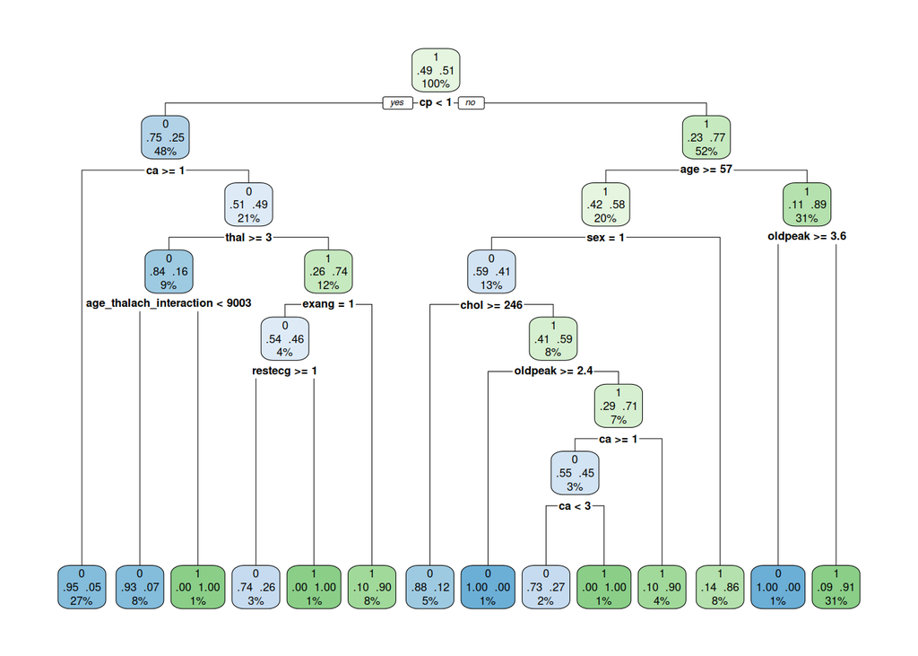

```r
# Visualize the decision tree
rpart.plot(tree_model, extra=104)  # Provides a detailed visual of the tree
```